# Lecture 5: Sampling, Estimation and Statistical Inference Workshop

#### D) ii) Prediction Intervals

1. Develop 99% prediction intervals for `Age` of a new customer. Interpret your results.

**Check if `Age` variable is normally distributed. If it is not, we need to transform the variable before we can apply the PI formula. Below we show how we derive the PI with 1) original data, 2) log10 transformed data, 3) applying transformTukey(). If we transform the original values, we need to remember to reverse the transformation when we compute the PI.**

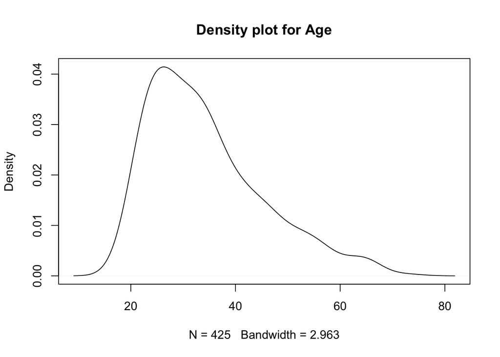

```r
plot(density(BD$Age),main="Density plot for Age") # distribution looks a little right skewed...
```

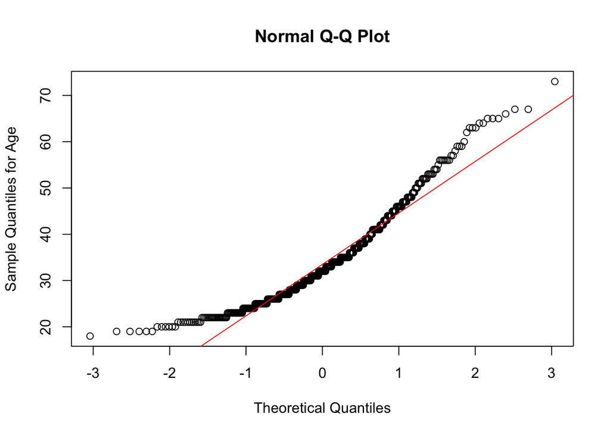

```r
qqnorm(BD$Age,
       ylab="Sample Quantiles for Age")
qqline(BD$Age,
       col="red")
```

```r
shapiro.test(BD$Age)
```

```
##
##  Shapiro-Wilk normality test
##
## data:  BD$Age
## W = 0.92301, p-value = 6.026e-14
```

```r
#computation with original data
mnage <- mean(BD$Age)
sdage <- sd(BD$Age)
n.bd <- nrow(BD)
uPI.age <- mnage + (qt(0.995, df = (n.bd-1))*sdage*sqrt(1+1/n.bd))
lPI.age <- mnage - (qt(0.995, df = (n.bd-1))*sdage*sqrt(1+1/n.bd))
cbind(lPI.age, uPI.age)
```

```
##       lPI.age  uPI.age
## [1,] 5.785066 63.01023
```

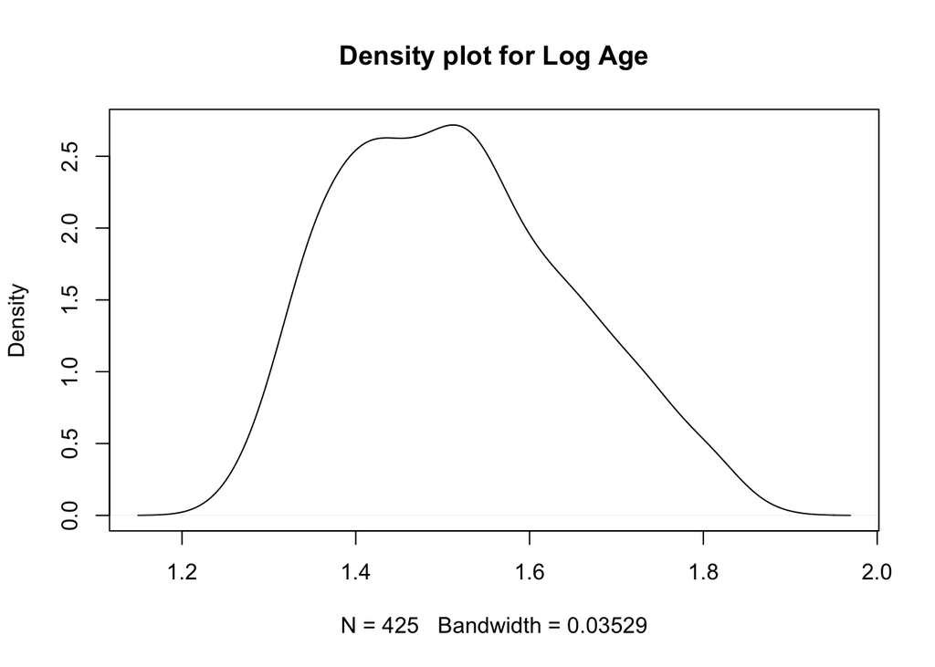

```r
# The 99% prediction interval for the age of a new customer is
#[5.785066 63.01023]

#transform `Age` using log10
BD$lgage<-log10(BD$Age)
plot(density(BD$lgage),main="Density plot for Log Age") # distribution looks quite normal...
```

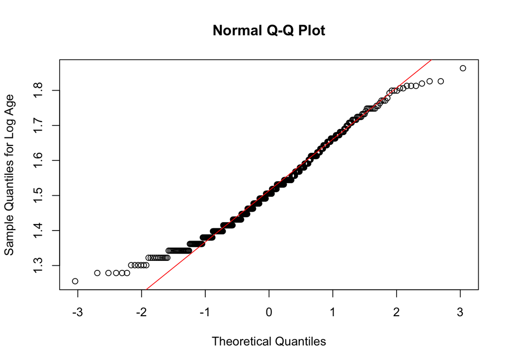

```r
qqnorm(BD$lgage,
       ylab="Sample Quantiles for Log Age")
qqline(BD$lgage,
       col="red")
```

```r
shapiro.test(BD$lgage) # W = 0.97551, p-value = 1.413e-06, closer to perfect normal distribution cf untransformed data
```

```
##
##  Shapiro-Wilk normality test
##
## data:  BD$lgage
## W = 0.97551, p-value = 1.413e-06
```

```r
#using log transformation to compute the PI
mnlage <- mean(BD$lgage)
sdlage <- sd(BD$lgage)
uPI.lage <- mnlage + (qt(0.995, df = (n.bd-1))*sdlage*sqrt(1+1/n.bd))
lPI.lage <- mnlage - (qt(0.995, df = (n.bd-1))*sdlage*sqrt(1+1/n.bd))
cbind(lPI.lage, uPI.lage)
```

```
##      lPI.lage uPI.lage
## [1,] 1.175264 1.856782
```

```r
#        lPI.lage uPI.lage
#   [1,] 1.175264 1.856782

cbind(10^(lPI.lage),10^(uPI.lage)) # inverse transformation
```

```
##          [,1]     [,2]
## [1,] 14.97145 71.90882
```

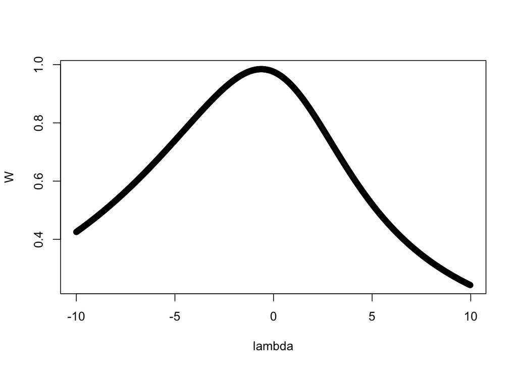

```
##
##     lambda      W Shapiro.p.value
## 375  -0.65 0.9845       0.0001634
##
## if (lambda >  0){TRANS = x ^ lambda}
## if (lambda == 0){TRANS = log(x)}
## if (lambda <  0){TRANS = -1 * x ^ lambda}
```

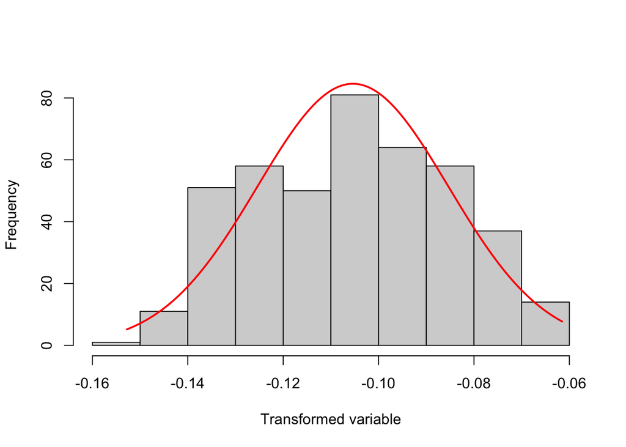

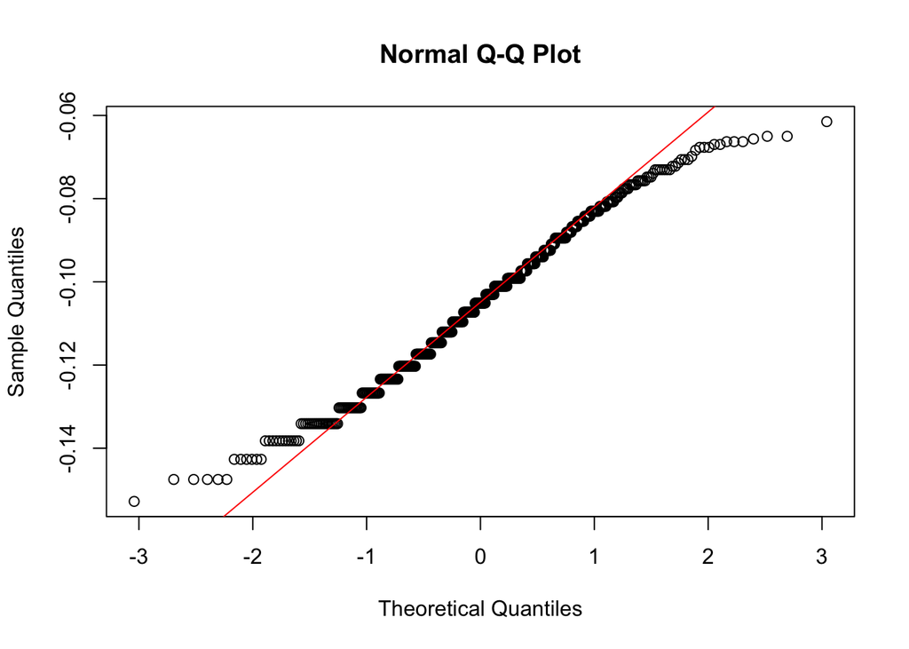

```r
# The 99% prediction interval for the age of a new customer is
#[14.97145 71.90882]

#transform data to normal distribution using transformTukey
BD$Age.t = transformTukey(BD$Age, plotit=TRUE)
```

```r
#using -1 * x ^ lambda where lambda = -0.65
mnage.t <- mean(BD$Age.t)
sdage.t <- sd(BD$Age.t)
uPI.aget <- mnage.t + (qt(0.995, df = (n.bd-1))*sdage.t*sqrt(1+1/n.bd))
lPI.aget <- mnage.t - (qt(0.995, df = (n.bd-1))*sdage.t*sqrt(1+1/n.bd))
cbind(lPI.aget, uPI.aget)
```

```
##        lPI.aget    uPI.aget
## [1,] -0.1573027 -0.05346039
```

```r
#  lPI.aget    uPI.aget
# [1,] -0.1573027 -0.05346039

#reverse transform; comments below is to derive the formula
# y=-1*x^lamda
# -y = x^-0.65 = 1/(x^0.65)
# x^0.65 = -1/y
# x = (-1/y)^(1/0.65)
lPI.age2 <- (-1/lPI.aget)^(1/0.65)
uPI.age2<- (-1/uPI.aget)^(1/0.65)

cbind(lPI.age2,uPI.age2) # reverse transform
```

```
##      lPI.age2 uPI.age2
## [1,] 17.21039 90.54691
```

```r
# The 99% prediction interval for the age of a new customer is
#[17.21039 90.54691]
```

As seen above, the 99% prediction intervals are sensitive to the transformation methods you used.

We generated 3 99% Prediction Intervals above: 1) [5.785066, 63.01023]; 2) [14.97145, 71.90882]; 3) [17.21039, 90.54691]

Interpretation for this [17.21039 90.54691]  
Given the observed loan customer age, the age for a new loan customer will lie within this interval with 99% level of confidence. More generally, with repeated random sampling, 99% of such constructed predictive intervals would contain the new loan customer age.

### E) Hypothesis Testing

#### E) i) Comparison of Mean Sample Age to Mean Population Age

**The Loan office manager makes the following claims below. Test his hypothesis using the data available.**

- 1. mean `Age` of all their customers is 35.
- 2. mean `Age` of all their customers is less than 40.

```r
nBD=nrow(BD)
#part i is two tailed test
#manual computation
ti<- (mean(BD$Age)-35)/(sd(BD$Age)/sqrt(nBD)) # t-value=-1.124
2*(pt(ti, nBD-1)) # p-value is 0.26153
```

```
## [1] 0.26153
```

```r
#using t.test function
t.test(BD$Age,
       alternative="two.sided",
       mu=35,
       conf.level = 0.95)
```

```
##
##  One Sample t-test
##
## data:  BD$Age
## t = -1.1243, df = 424, p-value = 0.2615
## alternative hypothesis: true mean is not equal to 35
## 95 percent confidence interval:
##  33.34456 35.45074
## sample estimates:
## mean of x
##  34.39765
```

```r
# what if we are testing if mean Age of all customers is 36?
t.test(BD$Age,
       alternative="two.sided",
       mu=36,
       conf.level = 0.95)
```

```
##
##  One Sample t-test
##
## data:  BD$Age
## t = -2.9908, df = 424, p-value = 0.002945
## alternative hypothesis: true mean is not equal to 36
## 95 percent confidence interval:
##  33.34456 35.45074
## sample estimates:
## mean of x
##  34.39765
```

```r
#part ii
t.test(BD$Age,
       alternative="less",
       mu=40,
       conf.level = 0.95)
```

```
##
##  One Sample t-test
##
## data:  BD$Age
## t = -10.457, df = 424, p-value < 2.2e-16
## alternative hypothesis: true mean is less than 40
## 95 percent confidence interval:
##      -Inf 35.28084
## sample estimates:
## mean of x
##  34.39765
```

- 1. H0: population mean age=35 ; H1: population mean age!= 35  
     Based on the results (t=-1.12 & p-value=0.2615 > 0.05), we do not have sufficient evidence to reject H0. Hence our sample data does not provide sufficient evidence to reject that population mean age is significantly different from 35 at the 5% level of significance.  
     Note in the output, the CI is [33.34,35.45]. Using the CI method, since 35 lies within the 95% CI, we can also say that we cannot reject H0 at the 95% confidence level. If we are testing if population mean age is 36, we can see now the p-value is less than 0.05 and 36 is also outside of the CI.
- 2. H0: population mean age >= 40 ; H1: population mean age< 40  
     Based on the results (t=-10.46 & p-value=2.2e-16 <0.05), we have sufficient evidence to reject H0 and accept that the population mean age is significantly less than 40 at the 5% level of significance.

#### E) ii) Comparison of Sample Proportion & Population Proportion of customers Age being >50

**The Loan office manager would like to check if the population proportion of customers with `Age` > 50 is at least 0.18. Test his hypothesis using the data available. (note: if alpha is not specified, use 0.05)**

```r
# compute z-statistic for proportion
age50<- BD %>% filter(Age>50)
p50 <- nrow(age50)/nrow(BD)
z <- (p50 - 0.18) / sqrt(0.18*(1-0.18)/nrow(BD))
z
```

```
## [1] -3.977159
```

```r
#compute critical value
cv.age50<-qnorm(0.05)
cv.age50
```

```
## [1] -1.644854
```

```r
z<cv.age50
```

```
## [1] TRUE
```

-Set up the hypothesis: H0: p >= 0.18; H1: p < 0.18 (Note here we have put the hypothesis we want to test as H0 because the equal sign is there)  
- From our results (z-statistic=-3.98 & z-critical=-1.64), the z-statistic is lying in the lower critical region. Thus we have sufficient evidence to reject H0 and accept that proportion of `Age` is less than 0.18 at the 5% level of significance.

#### E) iii) Comparison of Mean Age between Two Loan Purpose

**The credit risk manager wants to drill down to 5 types of Loan Purpose: Used Car, New Car, Small Appliance, Furniture, Business. He wants to see if the mean age differs between customers applying to these Loans:**

- 1. Used Car vs New Car
- 2. Business vs Small Appliance

```r
#create dataframe for each loan purpose mgr is interested in
usecar<- BD %>% filter(`Loan Purpose`== "Used Car")
newcar<- BD %>% filter(`Loan Purpose`== "New Car")
smapp<- BD %>% filter(`Loan Purpose`== "Small Appliance")
furn<- BD %>% filter(`Loan Purpose`== "Furniture")
bus <- BD %>% filter(`Loan Purpose`== "Business")

# count number of records for each Loan Purpose
lapply(list(usecar,newcar,smapp,furn,bus), nrow)
```

```
## [[1]]
## [1] 40
##
## [[2]]
## [1] 104
##
## [[3]]
## [1] 105
##
## [[4]]
## [1] 85
##
## [[5]]
## [1] 44
```

```r
# Age data is not normally distributed. However, given that the samples are large enough (say N>30), using CLT, we can assume that the sampling distribution of means will be approximately normal. Hence we can use t.test to compare the means.
#combine all dataframe to BD.less to contain  records of the 5 loan purposes

#conduct required t.test on Age
t.test(usecar$Age, newcar$Age)
```

```
##
##  Welch Two Sample t-test
##
## data:  usecar$Age and newcar$Age
## t = 0.12324, df = 73.482, p-value = 0.9023
## alternative hypothesis: true difference in means is not equal to 0
## 95 percent confidence interval:
##  -3.588214  4.061291
## sample estimates:
## mean of x mean of y
##  35.65000  35.41346
```

```r
t.test(bus$Age, smapp$Age)
```

```
##
##  Welch Two Sample t-test
##
## data:  bus$Age and smapp$Age
## t = 0.24864, df = 76.046, p-value = 0.8043
## alternative hypothesis: true difference in means is not equal to 0
## 95 percent confidence interval:
##  -3.685642  4.737157
## sample estimates:
## mean of x mean of y
##  34.65909  34.13333
```

-i) H0: Mean Age for Used Car = Mean Age for New Car; H1: Mean Age for Used Car != Mean Age for New Car  
The Welch t test results show we have insufficient evidence to reject H0 (t=0.123, p=0.9023 >0.05). Hence, we cannot conclude that there is significant difference between mean age of customers applying for Used Car vs those applying to New Car loans, at the 5% level of significance.

-ii) H0: Mean Age for Business = Mean Age for Small Appliance; H1: Mean Age for Business != Mean Age for Small Appliance  
The Welch t test results show we have insufficient evidence to reject H0 (t=0.249, p=0.8043 >0.05). Hence, we cannot conclude that there is significant difference between mean age of customers applying for Business vs Small Appliance loans, at the 5% level of significance.

#### E) iv) Comparison of Mean Age across all Five Loan Purpose Types

**Since there are more than 2 means to compare here, we will consider using ANOVA. However, we need to first check if the assumptions of ANOVA as follows are met:**

- 1. measures are randomly and independently obtained (assume this is true; random sample)
- 2. normally distributed (no but ANOVA is quite robust to deviations from normality)
- 3. equal variances across populations (we need to check if sample sizes are equal, if not then we need to check this)

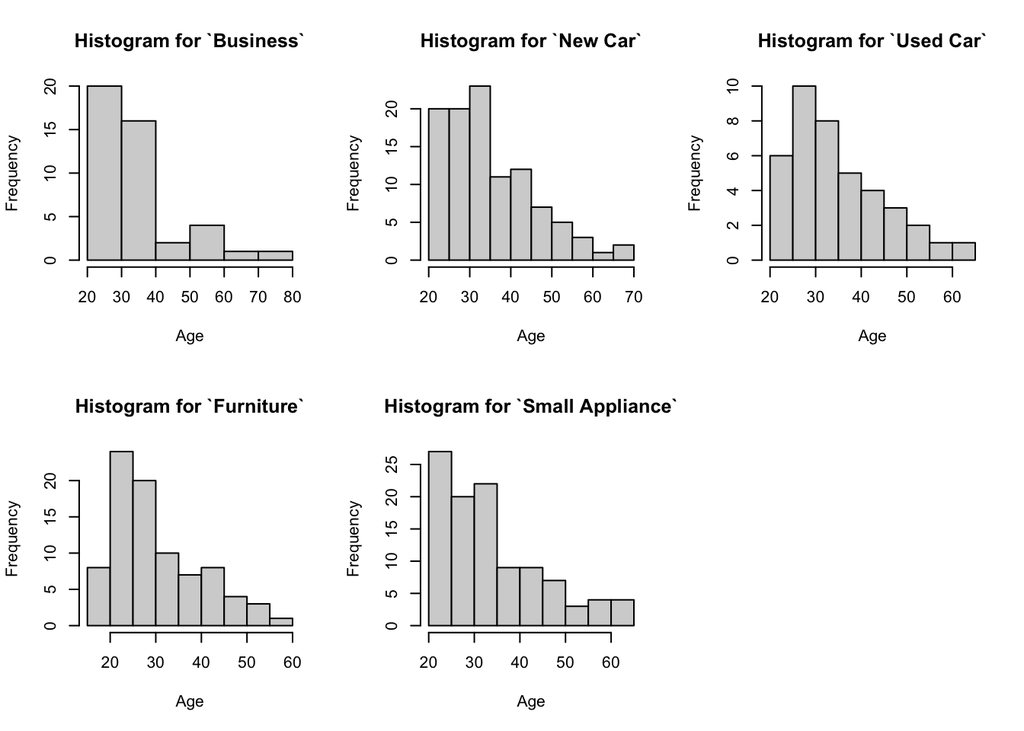

```r
# combine all 5 loan purpose records into one dataframe
BD.less<-rbind(usecar,newcar,smapp,furn, bus)

#Conduct ANOVA on Age
# plot histogram for Age
par(mfcol=c(2,3))
hist(bus$Age, main="Histogram for `Business`", xlab="Age")
hist(furn$Age, main="Histogram for `Furniture`", xlab="Age")
hist(newcar$Age, main="Histogram for `New Car`", xlab="Age")
hist(smapp$Age, main="Histogram for `Small Appliance`", xlab="Age")
hist(usecar$Age, main="Histogram for `Used Car`", xlab="Age")

# plot qqplots
par(mfcol=c(2,3))
```

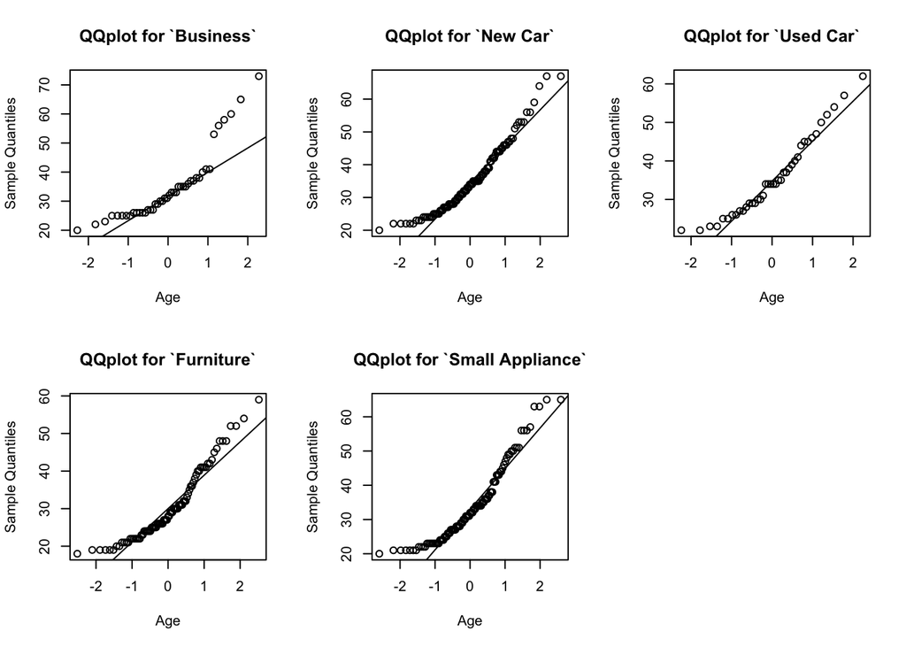

```r
qqnorm(bus$Age, main="QQplot for `Business`", xlab="Age")
qqline(bus$Age)
qqnorm(furn$Age, main="QQplot for `Furniture`", xlab="Age")
qqline(furn$Age)
qqnorm(newcar$Age, main="QQplot for `New Car`", xlab="Age")
qqline(newcar$Age)
qqnorm(smapp$Age, main="QQplot for `Small Appliance`", xlab="Age")
qqline(smapp$Age)
qqnorm(usecar$Age, main="QQplot for `Used Car`", xlab="Age")
qqline(usecar$Age)


# plot boxplots
par(mfcol=c(1,1))
```

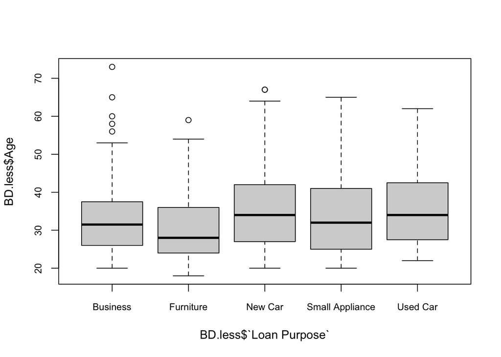

```r
boxplot(BD.less$Age ~ BD.less$`Loan Purpose`, cex.axis=0.8)
```

```r
# Shapiro Wilk Test
lapply(list(bus,furn,newcar,smapp,usecar),
       function(sa)
         {
         shapiro.test(sa$Age)
         })
```

```
## [[1]]
##
##  Shapiro-Wilk normality test
##
## data:  sa$Age
## W = 0.8244, p-value = 1.037e-05
##
##
## [[2]]
##
##  Shapiro-Wilk normality test
##
## data:  sa$Age
## W = 0.91021, p-value = 1.996e-05
##
##
## [[3]]
##
##  Shapiro-Wilk normality test
##
## data:  sa$Age
## W = 0.92831, p-value = 2.836e-05
##
##
## [[4]]
##
##  Shapiro-Wilk normality test
##
## data:  sa$Age
## W = 0.9028, p-value = 1.162e-06
##
##
## [[5]]
##
##  Shapiro-Wilk normality test
##
## data:  sa$Age
## W = 0.93815, p-value = 0.02998
```

```r
# check if sample sizes are equal to see if equal variance assumption is important to meet
table(BD.less$`Loan Purpose`)
```

```
##
##        Business       Furniture         New Car Small Appliance        Used Car
##              44              85             104             105              40
```

```r
# Since sample sizes are not equal, check if equal variance assumption is met
fligner.test(Age ~ `Loan Purpose`,BD.less)
```

```
##
##  Fligner-Killeen test of homogeneity of variances
##
## data:  Age by Loan Purpose
## Fligner-Killeen:med chi-squared = 1.8141, df = 4, p-value = 0.7699
```

```r
#if you want to try running levene's test, you need to install library(car) first
# leveneTest(Age~`Loan Purpose`,BD.less)

#fligner.test gave p=0.7699 > 0.05. Hence we cannot reject H0 that variances are equal. Based on this result, we proceed to conduct ANOVA test.

#ANOVA on SAVINGS
BD.less$`Loan Purpose`<-as.factor(BD.less$`Loan Purpose`)
aov.age<-aov(BD.less$Age ~ BD.less$`Loan Purpose`) #note the group variable should be a factor
summary(aov.age)
```

```
##                         Df Sum Sq Mean Sq F value Pr(>F)
## BD.less$`Loan Purpose`   4   1364   341.1    2.99 0.0189 *
## Residuals              373  42542   114.1
## ---
## Signif. codes:  0 '***' 0.001 '**' 0.01 '*' 0.05 '.' 0.1 ' ' 1
```

```r
TukeyHSD(aov.age)
```

```
##   Tukey multiple comparisons of means
##     95% family-wise confidence level
##
## Fit: aov(formula = BD.less$Age ~ BD.less$`Loan Purpose`)
##
## $`BD.less$`Loan Purpose``
##                                 diff        lwr       upr     p adj
## Furniture-Business        -4.1414439 -9.5782916  1.295404 0.2273856
## New Car-Business           0.7543706 -4.5103577  6.019099 0.9949572
## Small Appliance-Business  -0.5257576 -5.7830274  4.731512 0.9987583
## Used Car-Business          0.9909091 -5.4045456  7.386364 0.9931891
## New Car-Furniture          4.8958145  0.6153304  9.176299 0.0158279
## Small Appliance-Furniture  3.6156863 -0.6556209  7.886993 0.1406841
## Used Car-Furniture         5.1323529 -0.4807585 10.745464 0.0913658
## Small Appliance-New Car   -1.2801282 -5.3300808  2.769824 0.9089848
## Used Car-New Car           0.2365385 -5.2100266  5.683104 0.9999546
## Used Car-Small Appliance   1.5166667 -3.9226892  6.956023 0.9406203
```

```r
#If fligner test provides evidence that the variances are not equal, then we need to run the Welch ANOVA test, followed by Games Howell multiple comparison test.
BD.less$Loan<-BD.less$`Loan Purpose`
wa.out <- BD.less %>% welch_anova_test(Age ~ Loan)
gh.out <- games_howell_test(BD.less, Age ~ Loan) # games howell test does not assume normality and equal variances
wa.out
```

```
## # A tibble: 1 × 7
##   .y.       n statistic   DFn   DFd     p method
## * <chr> <int>     <dbl> <dbl> <dbl> <dbl> <chr>
## 1 Age     378      3.48     4  142.  0.01 Welch ANOVA
```

```r
gh.out
```

```
## # A tibble: 10 × 8
##    .y.   group1          group2          estimate conf.low conf.high p.adj p.adj.signif
##  * <chr> <chr>           <chr>              <dbl>    <dbl>     <dbl> <dbl> <chr>
##  1 Age   Business        Furniture         -4.14    -9.97       1.69 0.282 ns
##  2 Age   Business        New Car            0.754   -5.08       6.59 0.996 ns
##  3 Age   Business        Small Appliance   -0.526   -6.43       5.38 0.999 ns
##  4 Age   Business        Used Car           0.991   -5.77       7.75 0.994 ns
##  5 Age   Furniture       New Car            4.90     0.859      8.93 0.009 **
##  6 Age   Furniture       Small Appliance    3.62    -0.527      7.76 0.119 ns
##  7 Age   Furniture       Used Car           5.13    -0.223     10.5  0.067 ns
##  8 Age   New Car         Small Appliance   -1.28    -5.44       2.88 0.915 ns
##  9 Age   New Car         Used Car           0.237   -5.13       5.60 1     ns
## 10 Age   Small Appliance Used Car           1.52    -3.93       6.96 0.936 ns
```

H0: Mean Age is the same for all 5 Loan Purpose; H1: Mean Age for at least one Loan Purpose is different from the others

From ANOVA test results, we found sufficient evidence to reject H0 (F=2.99, p<0.05) and conclude that the mean age of customers applying to at least one 1 of the 5 loan purpose is significantly different from the others.

To check which pairs of loan purposes differ significantly in mean Age of their customers, we conduct the Tukey Multiple Comparison test. The results show that only one pair `New Car-Furniture` has significant difference in mean Age (mean diff=4.90, p adj=0.016)

We can perform the Games-Howell Test which does not assume normality and equal variances across samples. The test result is consistent with the Tukey Multiple Comparison test, show that only one pair `New Car-Furniture` has significant differences in mean Age (mean diff=4.90, p adj=0.009)

# CLT simulation

## a) Data is from binomial distribution

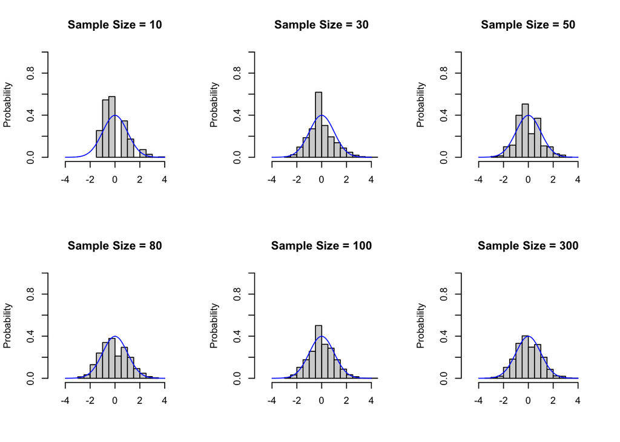

## b) Data is from normal distribution

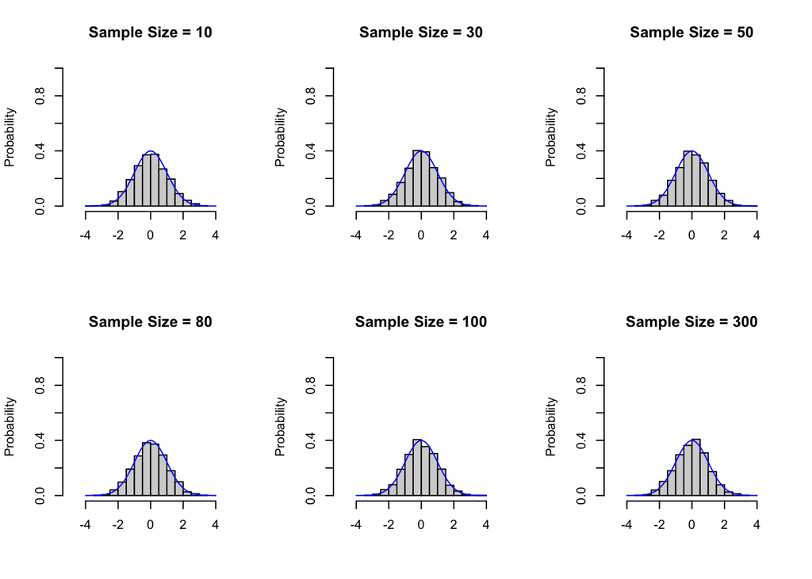

Links for you to play with constructing different CIs and sampling distributions (also used in class demo):

- http://digitalfirst.bfwpub.com/stats_applet/stats_applet_4_ci.html
- http://digitalfirst.bfwpub.com/stats_applet/stats_applet_3_cltmean.html
- http://www.ltcconline.net/greenl/java/Statistics/clt/cltsimulation.html